# Animal Shelter

Nayan Saikia

May 12, 2016

## Abstract:

Through out the country, there is large number of our furry friends that fall into neglect and dispair. Some of them survive their ordeal and find some kind hearted human being to call as companion, but many do not make it through - either by deliberate human action (Euthanasia) or due to sickness. This project is an attempt to bring awareness to their plights. Focus will be on dogs and cats are they are most commonly occuring pets. The project will encompass two objective:

### 1. General statistics:

Using data from Maddie’s Fund (www.maddiesfund.org), draw some insight into various outcomes such as adoption, death, euthanasia, returned to owner, and transferred.

### 2. ML model to predict outcome:

Build a prediction model based on data from Austin Animal Center (sourced from Kaggle.com) to predict likely hood of each of the outcomes stated above.

## 1. General Statistics:

The data from Maddie’s Fund is aggregated across 29 states and numerous communities and animal shelters. The features provide aggregated data of pets that come in either as transfer, from within the community, outside the community. It also provides total adopted, died, returned to owner (RTO), transfer and Euthanasia by state and communities/shelters. The dataset is available at https://github.com/Psychkya/Data-Sciences/tree/master/AnimalShelter  
Let us first look at statistics for dogs. The code to cleanse and summarize data is available at. https://github.com/Psychkya/Data-Sciences/tree/master/AnimalShelter

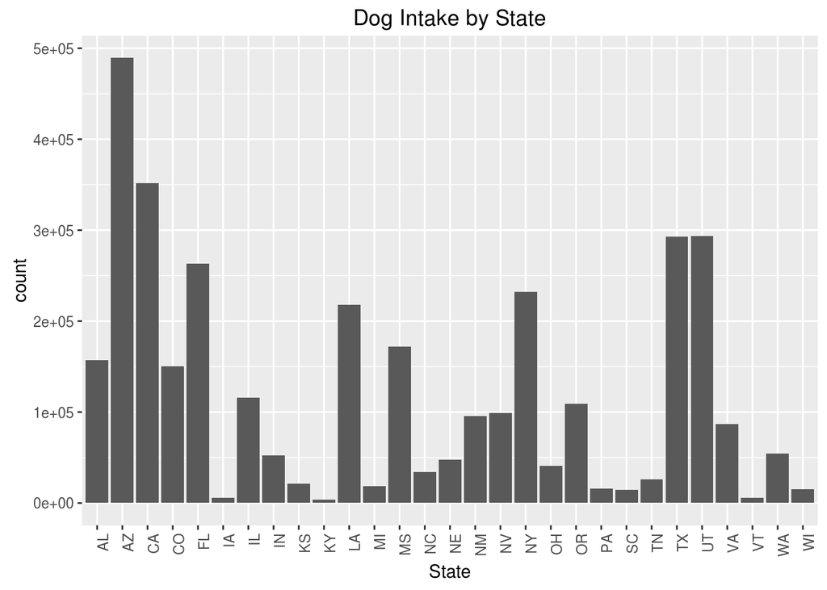

The total intake across all 29 states is about 3.5 million. That is a huge number. The numbers for respective states speaks for themselves.  
Lets look at the outcomes across all the states.

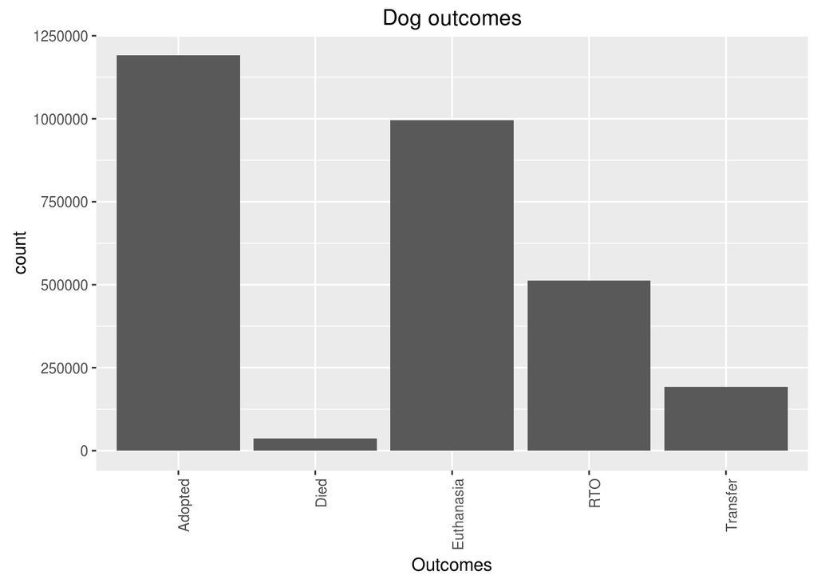

It is sad to see that Euthanasia is almost the same numbers as adopted. Lets draw some similar statistics on cats.

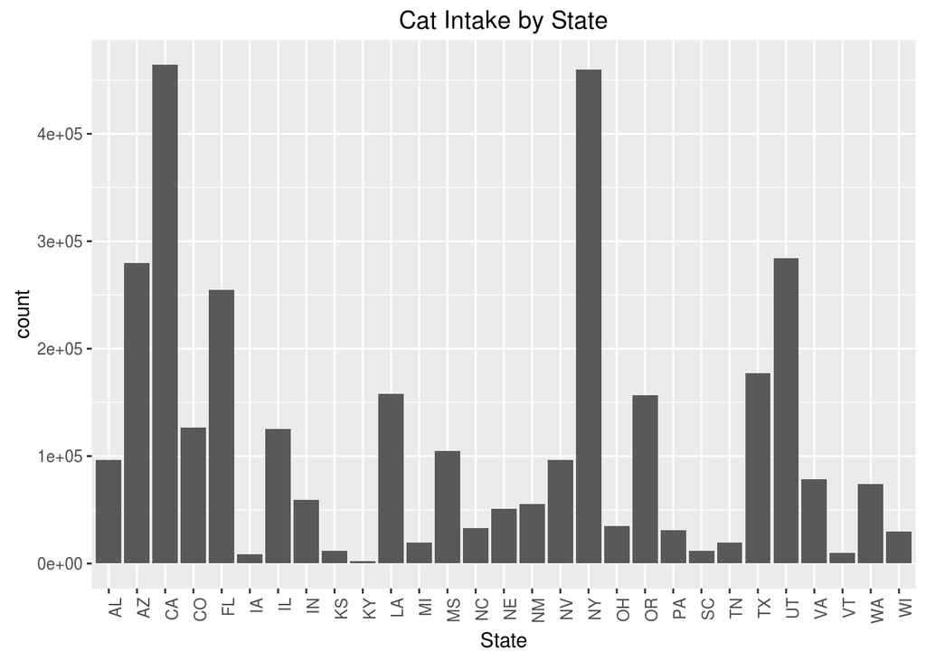

The number of cat intake is also around 3.3 million.

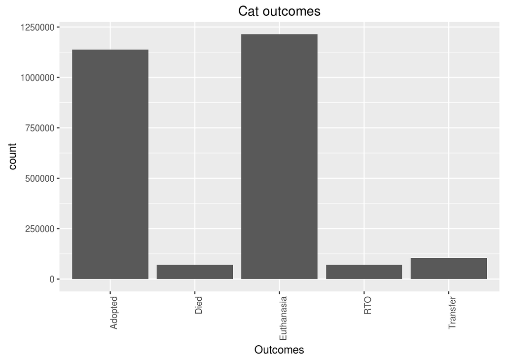

The state of cats is more sad. The number of cats being euthanised is more than adopted. Although, one thing that is not apparent here is how many of those cats or dogs are euthanised due to owner request (pet is suffering due to illness or old age). There is an owner request euthanization feature available in the data.

## 2. ML model to predict outcomes

### Data intake:

```r
shelter.trn <- read.csv('/home/awaz/Documents/UISCourses/DataScience/AnimalShelter/train.csv')
shelter.tst <- read.csv('/home/awaz/Documents/UISCourses/DataScience/AnimalShelter/test.csv')
```

A quick look at the structure shows that all the features are categorical. There are some features that has a lot of levels, which may cause issue with certain algorithm. We will try to clean these features as best as possible.

```r
str(shelter.trn)
```

```
## 'data.frame':    26729 obs. of  10 variables:
##  $ AnimalID      : Factor w/ 26729 levels "A006100","A047759",..: 5420 1604 11614 10239 3502 7396 17152 18183 5373 7574 ...
##  $ Name          : Factor w/ 6375 levels "","007","3Buster",..: 2350 1846 4438 1 1 1833 2759 1 3456 1 ...
##  $ DateTime      : Factor w/ 22918 levels "2013-10-01 09:31:00",..: 3362 351 12682 7191 1234 5022 13873 14619 3214 5210 ...
##  $ OutcomeType   : Factor w/ 5 levels "Adoption","Died",..: 4 3 1 5 5 5 5 5 1 1 ...
##  $ OutcomeSubtype: Factor w/ 17 levels "","Aggressive",..: 1 17 8 14 14 14 14 14 1 13 ...
##  $ AnimalType    : Factor w/ 2 levels "Cat","Dog": 2 1 2 1 2 2 1 1 2 2 ...
##  $ SexuponOutcome: Factor w/ 6 levels "","Intact Female",..: 4 5 4 3 4 2 3 6 5 5 ...
##  $ AgeuponOutcome: Factor w/ 45 levels "","0 years","10 months",..: 19 19 24 27 24 16 27 27 34 19 ...
##  $ Breed         : Factor w/ 1380 levels "Abyssinian Mix",..: 1230 644 1093 644 914 369 644 644 52 365 ...
##  $ Color         : Factor w/ 366 levels "Agouti","Agouti/Brown Tabby",..: 131 175 87 46 275 36 69 119 251 319 ...
```

We will combine the train and test set to cleanse the data. We will remove the ID column from both set. Additionally, we will remove the outcomesubtype column from the train set. This column is not available in the test set.

```r
#Outcome subtype is not available in test. So lets remove it from train along with ID
shelter.train <- shelter.trn[,-c(1,5)]
shelter.test <- shelter.tst[,-1]
#Add Outcometype to test set and fill it with NA
shelter.test$OutcomeType <- NA
#Reorder test to be same as train
shelter.test <- shelter.test[,c("Name","DateTime","OutcomeType","AnimalType", "SexuponOutcome","AgeuponOutcome","Breed","Color")]
#Combine the two dataframes for cleansing
shelter.df <- rbind(shelter.train,shelter.test)
```

We will start at the bottom and engineer each feature.

### Color:

Color has 411 levels. Many of the color levels are combination of two colors, example, white/blue. The strategy here is to divide the feature color into two features - color1 and color2. The combination of the two features should provide pretty good information on color of the pet. Another strategy would have been to bin the colors into like colors and also convert colors occuring less frequently into a single level such as ‘other’. However, given the nature of the problem, we may end up losing important information that may affect outcome (someone may like a black and brindle dog over just a black dog!)

```r
for (i in 1:nrow(shelter.df)) {
  shelter.df$Color1[i] <- strsplit(as.character(shelter.df$Color[i]),"/")[[1]][1]
  shelter.df$Color2[i] <- strsplit(as.character(shelter.df$Color[i]),"/")[[1]][2]
}
```

There will be quite a few NA in Color2 as some of the levels in the original feature are not a combination. We will convert the NAs to a level such as ‘Not Applicable’.

```r
shelter.df$Color2[is.na(shelter.df$Color2)] <- "Not Applicable"
```

We are trying to retain as much information as we can and so we will not reduce color any further.

### Breed:

Next we will deal with Breed, which has quite a few level. Using the same strategy as color, we will split Breed into two features - Breed1 and Breed2.

```r
for (i in 1:nrow(shelter.df)) {
  shelter.df$Breed1[i] <- strsplit(as.character(shelter.df$Breed[i]),"/")[[1]][1]
  shelter.df$Breed2[i] <- strsplit(as.character(shelter.df$Breed[i]),"/")[[1]][2]
}
```

Breed1 and Breed2 still has a huge number of levels - approximately 400 and 200 respectively. One strategy could be to combine mix breed with non-mix - meaning, lab mix and lab becomes lab. Also, any like dogs such as american pit bull, pit bull, and straffordshire can be combined to ‘pit bull’. There is some difference between the breeds. But again, the strategy here is to retain maximum information and let the model weed out what is not needed. So, we will leave them alone. Multiple run of model indicated that leaving the information provides better result.  
There is a bit of cleaning that can be done.

```r
#Convert NA in Breed2 to 'Not Applicable'
shelter.df$Breed2[is.na(shelter.df$Breed2)] <- "Not Applicable"
shelter.df$Breed1[grep("Pit Bull", shelter.df$Breed1)] <- "Pit Bull"
shelter.df$Breed1[grep("Staffordshire", shelter.df$Breed1)] <- "Pit Bull"
shelter.df$Breed1[grep("Black", shelter.df$Breed1)] <- "Black Mouth Cur"
shelter.df$Breed1[grep("Chihuahua", shelter.df$Breed1)] <- "Chihuahua"
```

Breed1 and Breed2 still has too large of levels and so need a way to reduced them while staying true to the strategy of retaining information. A list of dog breeds and their intuitive sizes (based on height and weight) was compiled separately. The list provides whether a dog is large, medium or small in size. So, we break down Breed1 into three more features - LargeBreed1, MedumBreed1 and SmallBreed1. Same goes for Breed2. Hopefully, this will provide enough information to uniquely identify a dog breed.  
Some housekeeping to read in the list and make it ready for use.

```r
breedsize <- read.csv('/home/awaz/Documents/UISCourses/DataScience/AnimalShelter/BreedsizeFinal.csv',stringsAsFactors = FALSE)
breedsize <- breedsize[-which(breedsize$Size==""),]
#combine large, medium and small dog breeds into a single variable respectively. This will help with grep
smallbreed <- ""
largebreed <- ""
mediumbreed <- ""
for (i in 1:nrow(breedsize)) {
  if(breedsize$Size[i]=="Small"){
    smallbreed <- paste(smallbreed, breedsize$Breed[i], sep = " ")
  }
  if(breedsize$Size[i]=="Large"){
    largebreed <- paste(largebreed,breedsize$Breed[i],sep = " ")
  }
  if(breedsize$Size[i]=="Medium"){
    mediumbreed <- paste(mediumbreed,breedsize$Breed[i],sep = " ")
  }
}
largebreed <- trimws(largebreed)
mediumbreed <- trimws(mediumbreed)
smallbreed <- trimws(smallbreed)
```

The logic is to create three variables largbreed, smallbreed, and mediumbreed containing each of the dog breeds respectively. Then each of the dog breeds from the dataset will be grepped against these variables to move them to LargeBreed1, MediumBreed1, etc.

```r
shelter.df$LargeBreed1 <- NA
shelter.df$MediumBreed1 <- NA
shelter.df$SmallBreed1 <- NA
for (i in 1:nrow(shelter.df)) {
  x <- trimws(strsplit(shelter.df$Breed1[i],"Mix"))
  if(grepl(x[[1]][1],largebreed)){
    shelter.df$LargeBreed1[i] <- shelter.df$Breed1[i]
  }
  else if(grepl(x[[1]][1],mediumbreed)){
    shelter.df$MediumBreed1[i] <- shelter.df$Breed1[i]
  }
  else if(grepl(x[[1]][1],smallbreed)){
    shelter.df$SmallBreed1[i] <- shelter.df$Breed1[i]
  }
}
```

The list that was read in seems to have a few issues. Some breeds of cats are listed as large - all cats should be small. Also, a few breeds does not exist in the list. Further, for a given observation, a breed name will be in only one of the three new features. So we have a bit of clean-up to do.

```r
shelter.df$SmallBreed1[which(shelter.df$AnimalType=="Cat" & !is.na(shelter.df$LargeBreed1))] <-
                    shelter.df$LargeBreed1[which(shelter.df$AnimalType=="Cat" & !is.na(shelter.df$LargeBreed1))]
shelter.df$LargeBreed1[which(shelter.df$AnimalType=="Cat" & !is.na(shelter.df$LargeBreed1))] <- NA
shelter.df$SmallBreed1[which(shelter.df$AnimalType=="Cat" &
                    is.na(shelter.df$SmallBreed1) & is.na(shelter.df$MediumBreed1) & is.na(shelter.df$LargeBreed1))] <-
                    shelter.df$Breed1[which(shelter.df$AnimalType=="Cat" &
                                              is.na(shelter.df$SmallBreed1) & is.na(shelter.df$MediumBreed1) &
                                              is.na(shelter.df$LargeBreed1))]
shelter.df$SmallBreed1[grep("Coton De Tulear",shelter.df$Breed1)] <- shelter.df$Breed1[grep("Coton De Tulear",shelter.df$Breed1)]
shelter.df$SmallBreed1[grep("Dandie Dinmont",shelter.df$Breed1)] <- shelter.df$Breed1[grep("Dandie Dinmont",shelter.df$Breed1)]
shelter.df$SmallBreed1[grep("Eng Toy Spaniel",shelter.df$Breed1)] <- shelter.df$Breed1[grep("Eng Toy Spaniel",shelter.df$Breed1)]
shelter.df$LargeBreed1[grep("Unknown",shelter.df$Breed1)] <- shelter.df$Breed1[grep("Unknown",shelter.df$Breed1)]
shelter.df$LargeBreed1[grep("Gordon Setter",shelter.df$Breed1)] <- shelter.df$Breed1[grep("Gordon Setter",shelter.df$Breed1)]
shelter.df$SmallBreed1[grep("Dachshund Stan Mix",shelter.df$Breed1)] <- shelter.df$Breed1[grep("Dachshund Stan Mix",shelter.df$Breed1)]
#Convert all NA into some sort of level
shelter.df$SmallBreed1[is.na(shelter.df$SmallBreed1)] <- "Not Applicable"
shelter.df$LargeBreed1[is.na(shelter.df$LargeBreed1)] <- "Not Applicable"
shelter.df$MediumBreed1[is.na(shelter.df$MediumBreed1)] <- "Not Applicable"
```

We repeat the same process for Breed2.

```r
shelter.df$LargeBreed2 <- NA
shelter.df$MediumBreed2 <- NA
shelter.df$SmallBreed2 <- NA
for (i in 1:nrow(shelter.df)) {
  x <- trimws(strsplit(shelter.df$Breed2[i],"Mix"))
  if(grepl(x[[1]][1],largebreed)){
    shelter.df$LargeBreed2[i] <- shelter.df$Breed2[i]
  }
  else if(grepl(x[[1]][1],mediumbreed)){
    shelter.df$MediumBreed2[i] <- shelter.df$Breed2[i]
  }
  else if(grepl(x[[1]][1],smallbreed)){
    shelter.df$SmallBreed2[i] <- shelter.df$Breed2[i]
  }
}
shelter.df$SmallBreed2[which(shelter.df$AnimalType=="Cat" & !is.na(shelter.df$LargeBreed2))] <-
  shelter.df$LargeBreed2[which(shelter.df$AnimalType=="Cat" & !is.na(shelter.df$LargeBreed2))]
shelter.df$LargeBreed2[which(shelter.df$AnimalType=="Cat" & !is.na(shelter.df$LargeBreed2))] <- NA
shelter.df$LargeBreed2[which(shelter.df$Breed2=="Not Applicable")] <- "Not Applicable"
shelter.df$MediumBreed2[which(shelter.df$Breed2=="Not Applicable")] <- "Not Applicable"
shelter.df$SmallBreed2[which(shelter.df$Breed2=="Not Applicable")] <- "Not Applicable"
shelter.df$SmallBreed2[which(shelter.df$Breed2=="Unknown")] <- "Not Applicable"
shelter.df$MediumBreed2[which(shelter.df$Breed2=="Unknown")] <- "Not Applicable"
shelter.df$LargeBreed2[which(shelter.df$Breed2=="Unknown")] <- "Not Applicable"
shelter.df$SmallBreed2[which(shelter.df$Breed2=="Cirneco")] <- "Cirneco"
#Convert all NA into some sort of level
shelter.df$SmallBreed2[is.na(shelter.df$SmallBreed2)] <- "Not Applicable"
shelter.df$LargeBreed2[is.na(shelter.df$LargeBreed2)] <- "Not Applicable"
shelter.df$MediumBreed2[is.na(shelter.df$MediumBreed2)] <- "Not Applicable"
```

Looks like we are done with breed. Lets turn our focus to age.

### Age:

AgeuponOutcome is also categorical. It is either in years, months, weeks. The strategy here is simple, we will extract the numeric part of AgeuponOutcome and convert them all to weeks. The assumption is 52 weeks in a year and 4 weeks in a month.

```r
shelter.df$AgeuponOutcome <- as.character(shelter.df$AgeuponOutcome)
convertAge <- function(x){
  x <- ifelse(x!="",strsplit(x,"\\s")[[1]][1],x)
}
shelter.df$Age <- sapply(shelter.df$AgeuponOutcome,convertAge)
shelter.df$Age <- as.numeric(shelter.df$Age)
#convert age to weeks
for (i in 1:nrow(shelter.df)) {
  if(!is.na(shelter.df$Age[i])){
    if(grepl("year",shelter.df$AgeuponOutcome[i])){
      shelter.df$Age[i] <- floor(shelter.df$Age[i]*52)
    }
    else if(grepl("month",shelter.df$AgeuponOutcome[i])){
      shelter.df$Age[i] <- floor(shelter.df$Age[i]*4)
    }
    else if(grepl("week",shelter.df$AgeuponOutcome[i])){
      shelter.df$Age[i] <- floor(shelter.df$Age[i])
    }
  }
}
#Replace NA ages with mean
shelter.df$Age[is.na(shelter.df$Age)] <- mean(na.omit(shelter.df$Age))
```

### DateTime:

Date and time may not seem like an important feature. But prior interation of trying to predict reaveled that ‘Died’ had the worst accuracy. Perhaps, including at least the time part may provide the algorithm some incremental information about the outcomes. Adoption, Transfer, Euthanasia may not happen in the middle of the night, but a pet can certainly die at that time.  
We extract the hour and minute part and create only an hour field, rounding off to the closest hour.

```r
datetimesplt <- function(x){x <- strsplit(as.character(x),"\\s")[[1]][2]}
shelter.df$Time <- sapply(shelter.df$DateTime, datetimesplt)
#Convert Time to the closest hour
for (i in 1:nrow(shelter.df)) {
  t1 <- as.numeric(strsplit(shelter.df$Time[i],":")[[1]][1])
  t2 <- as.numeric(strsplit(shelter.df$Time[i],":")[[1]][2])
  shelter.df$TimeHour[i] <- ifelse(t2 > 30, t1+1, t1)
}
```

### Name:

The name itself (Rex, Balto, etc.) may not seem to have any significance, but the fact that the pet has a name may indicate that it is likely to be returned to owner or adopted. So, we will create a new feature called ‘HasName’ to say ‘Yes’ or ‘No’ based on whether a name exists.

```r
shelter.df$HasName <- ifelse(shelter.df$Name=="", "No", "Yes")
```

### SexuponOutcome:

This particular feature seems to be good as is - so no cleaning needed.

### Data Visualization:

Before we jump down to data visualization and building the model, we have a bit more housekeeping to do. Our original dataframe now has the original features as well as the new features we created. So let us carve out only the features we will use. Also, let us split back up the test and train set.

```r
shelter.XB <- shelter.df[,which(colnames(shelter.df) %in% c("OutcomeType","HasName","TimeHour", "AnimalType", "SexuponOutcome", "Color1", "Color2",
                                                            "Age","LargeBreed1","MediumBreed1","SmallBreed1","LargeBreed2",
                                                            "MediumBreed2","SmallBreed2"))]
shelter.XB$Color1 <- as.factor(shelter.XB$Color1)
shelter.XB$Color2 <- as.factor(shelter.XB$Color2)
shelter.XB$LargeBreed1 <- as.factor(shelter.XB$LargeBreed1)
shelter.XB$MediumBreed1 <- as.factor(shelter.XB$MediumBreed1)
shelter.XB$SmallBreed1 <- as.factor(shelter.XB$SmallBreed1)
shelter.XB$LargeBreed2 <- as.factor(shelter.XB$LargeBreed2)
shelter.XB$MediumBreed2 <- as.factor(shelter.XB$MediumBreed2)
shelter.XB$SmallBreed2 <- as.factor(shelter.XB$SmallBreed2)
shelter.XB$HasName <- as.factor(shelter.XB$HasName)
#Split original test and train
shelter.XB.Train <- shelter.XB[!is.na(shelter.XB$OutcomeType),]
shelter.XB.Test <- shelter.XB[is.na(shelter.XB$OutcomeType),]
```

```r
library(ggplot2)
library(polycor)
library(corrplot)
```

**Overall outcome:**

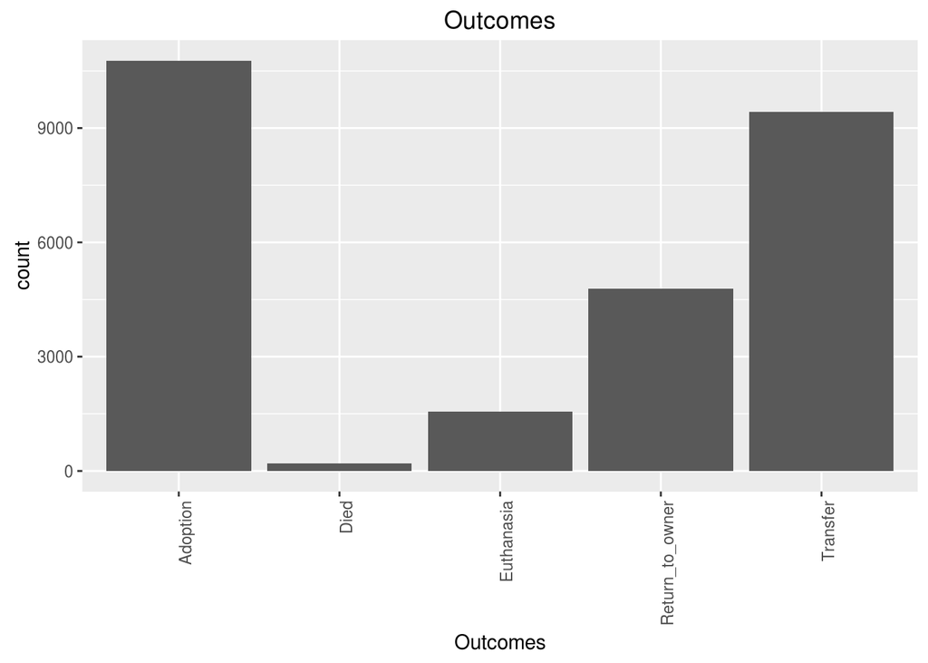

```r
ggplot(shelter.XB.Train,aes(shelter.XB.Train$OutcomeType,..count..)) + geom_bar() + xlab("Outcomes") + ylab("count") +
      ggtitle("Outcomes")  +
      theme(axis.text.x=element_text(angle = 90,hjust = 1))
```

The bar plot above shows a much better picture compared to the cumulative data we saw from Maddie’s Fund. This particular community seems to be successful in having pets adopted or transferred.

**Outcome vs Age:**

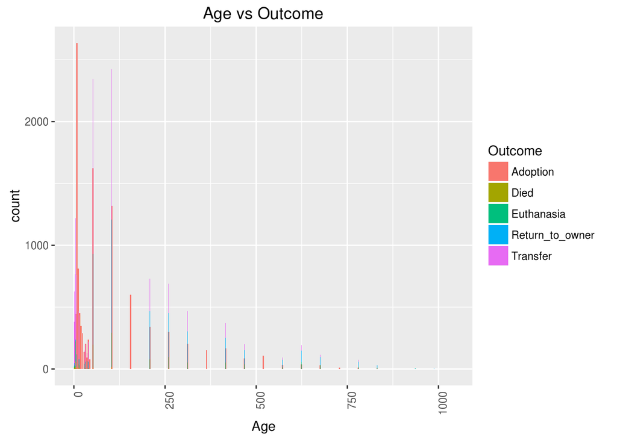

```r
ggplot(shelter.XB.Train,aes(shelter.XB.Train$Age,..count..
        )) + geom_bar(aes(fill=shelter.XB.Train$OutcomeType
        )) + xlab("Age") + ylab("count") + ggtitle("Age vs Outcome") + labs(fill = "Outcome") +
        theme(axis.text.x=element_text(angle = 90,hjust = 1))
```

There seems to be more activity in terms of adoption, transfered, etc. among young pets. Adption is highest at very young age, which makes sense. There does not seem to be a particular age group where the bleak outcomes dominate, which is a good thing (not from data science perspective, but humanity perspective!)

**Outcome vs Time:**

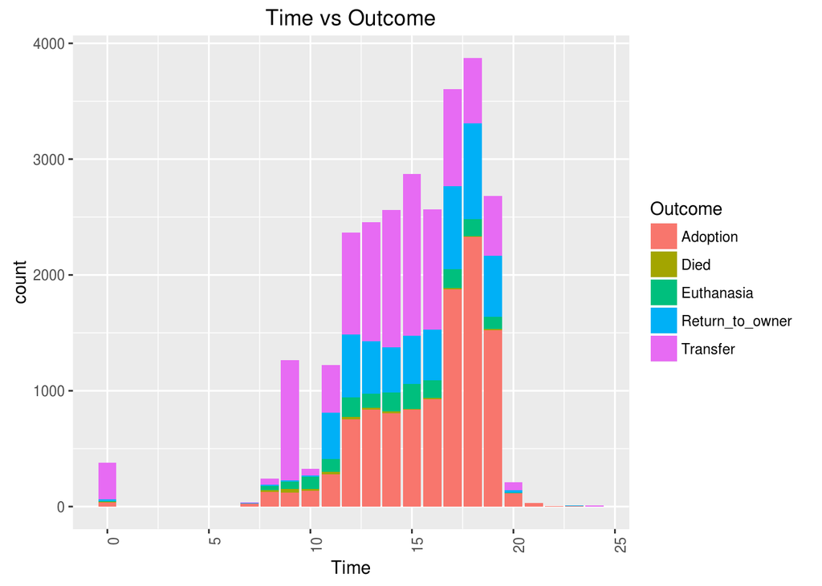

```r
ggplot(shelter.XB.Train,aes(shelter.XB.Train$TimeHour,..count..
        )) + geom_bar(aes(fill=shelter.XB.Train$OutcomeType
        )) + xlab("Time") + ylab("count") + ggtitle("Time vs Outcome") + labs(fill = "Outcome") +
        theme(axis.text.x=element_text(angle = 90,hjust = 1))
```

Most of the euthanasia happens sometime around noon and afternoon. Most of adoption occurs towards the evening.

**Animal type vs Outcome**

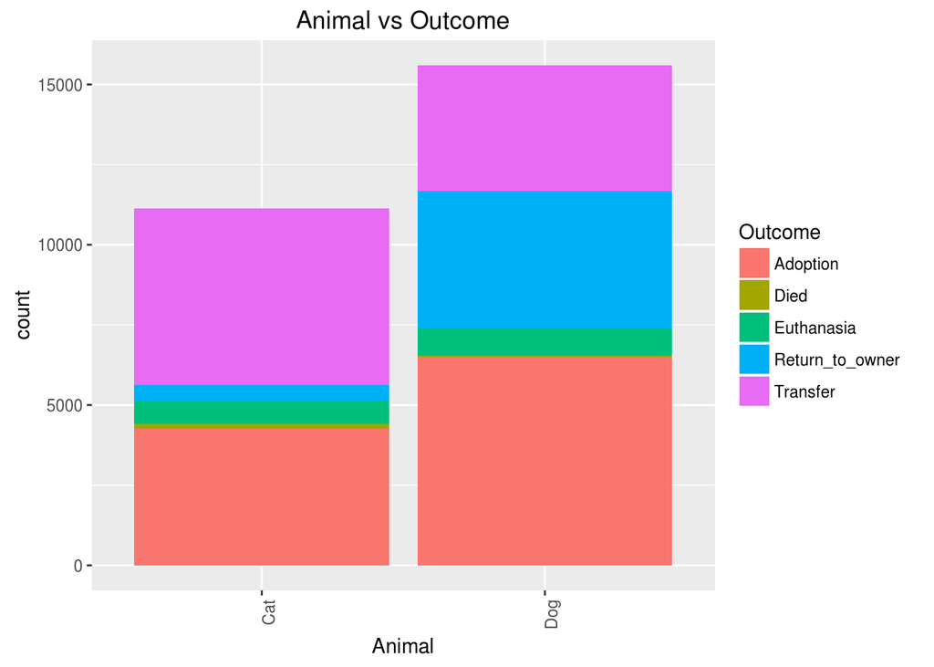

```r
ggplot(shelter.XB.Train,aes(shelter.XB.Train$AnimalType,..count..
        )) + geom_bar(aes(fill=shelter.XB.Train$OutcomeType
        )) + xlab("Animal") + ylab("count") + ggtitle("Animal vs Outcome") + labs(fill = "Outcome") +
        theme(axis.text.x=element_text(angle = 90,hjust = 1))
```

Dogs seems to be adopted more than cats, while cats seems to be transferred out more often. Also, dogs are returned to owner more often than cats.

**Has name vs Outcome**

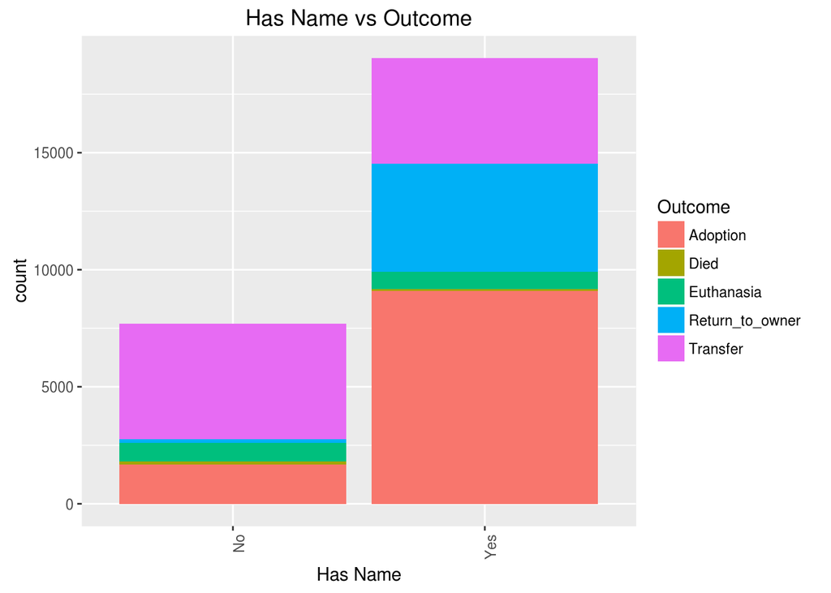

```r
ggplot(shelter.XB.Train,aes(shelter.XB.Train$HasName,..count..
        )) + geom_bar(aes(fill=shelter.XB.Train$OutcomeType
        )) + xlab("Has Name") + ylab("count") + ggtitle("Has Name vs Outcome") + labs(fill = "Outcome") +
        theme(axis.text.x=element_text(angle = 90,hjust = 1))
```

Would be nice to do a breed vs outcome, but the graph is too messy due to sheer number of breeds.

**Correlation Matrix**  
Let’s look at correlation matrix to see if there is any obvious strong correlation with Outcomtype.

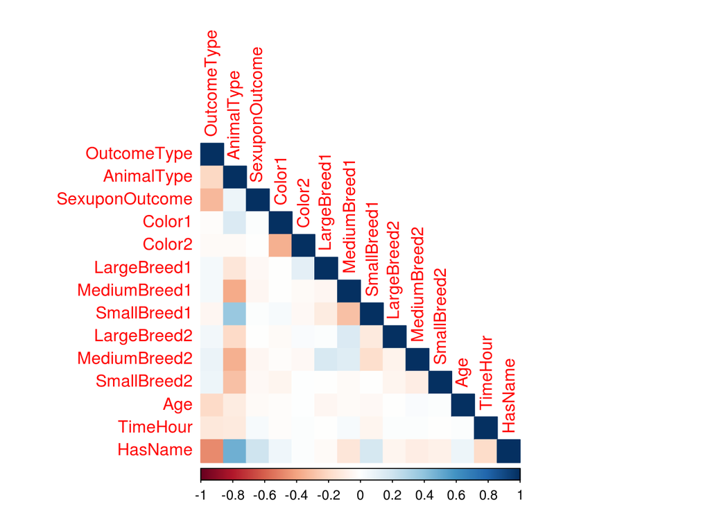

After all that work, the correlation matrix seems to be telling that breed and color does not have a huge impact on color. But let us proceed with a model.

**XGBOOST Model**  
Since we have a high number of levels for some of the features, we cannot use random forest. It has a limitation of only 53 levels per feature. Instead, we will use XGBOOST, which stands for ‘Extreme Gradiant Boosting’. It is a boosted tree algorithm and is quite popular with classification - although it can handle regression problems as well. XGBoost works with numeric data only - so we will need to convert our categorical data into numeric. Caret provides a good way of converting categorical into numeric.

```r
library(caret)
library(xgboost)
```

```r
dummies <- dummyVars(~.,data = shelter.XB.Train[,-c(1,12,14)])
tmp.train <- data.frame(predict(dummies, newdata = shelter.XB.Train[,-c(1,12,14)]))
tmp.train <- cbind(tmp.train,shelter.XB.Train[,c(12,14)])
```

XGBoost can only predict numeric classes. So we will convert our output classes to a numeric value. Per documentation of XGBoost, it should start with 0.

```r
#convert output label to numeric Adoption=0, Died=1, Euthanasia=2, Return_to_owner=3, Transfer=4
train.label <- rep(NA,nrow(tmp.train))
for(i in 1:nrow(tmp.train)) {
  switch (as.character(shelter.XB.Train$OutcomeType[i]),
    Adoption = {train.label[i] <- 0},
    Died = {train.label[i] <- 1},
    Euthanasia = {train.label[i] <- 2},
    Return_to_owner = {train.label[i] <- 3},
    Transfer = {train.label[i] <- 4},
    stop("Invalid case")
  )
}
```

We will carve out a validation set from the training set to make sure our model is good.

```r
tmp.train.tr <- tmp.train[1:16729,]
tmp.train.val <- tmp.train[16730:26729,]
train.label.tr <- train.label[1:16729]
train.label.val <- train.label[16730:26729]
```

Finally the model!! XGBoost is verbose in annoucing the error metric during execution, but we have it turned off using verbose=0. Change it to verbose=1 to see logloss for each tree.

```r
xb_model <- xgboost(data = data.matrix(tmp.train.tr), label = train.label.tr, max_depth = 6, nround = 100, eta = 0.1,
                    subsample = 1.0, eval_metric = "mlogloss", verbose = 0, objective = "multi:softprob", num_class = 5 )
```

And now prediction:

```r
pred <- predict(xb_model,data.matrix(tmp.train.val))
pred_df <-data.frame(matrix(pred, ncol=5, byrow = TRUE))
colnames(pred_df) <- c("Adoption","Died","Euthanasia","Return_to_owner","Transfer")
```

The predicted output is a numeric vector of class X validation observations. Since we will be using logloss as our metric, we converted the predicted output to a dataframe. This also means that we will have to convert our actual outcomes to a dataframe as well.

```r
Adoption <- rep(0,10000)
Died <- rep(0,10000)
Euthanasia <- rep(0,10000)
R2O <- rep(0,10000)
Transfer <- rep(0,10000)
for (i in 1:nrow(tmp.train.val)) {
  if(train.label.val[i]==0){
     Adoption[i] <- 1
  }
  else if(train.label.val[i]==1){
    Died[i] <- 1
  }
  else if(train.label.val[i]==2){
    Euthanasia[i] <- 1
  }
  else if(train.label.val[i]==3){
    R2O[i] <- 1
  }
  else if(train.label.val[i]==4){
    Transfer[i] <- 1
  }
}
actual <- data.frame(Adoption,Died,Euthanasia,R2O,Transfer)
colnames(actual) <- c("Adoption","Died","Euthanasia","Return_to_owner","Transfer")
```

We will use MLmetrics to calculate log loss

```r
library(MLmetrics)
m_actual <- as.matrix(actual)
m_results <- as.matrix(pred_df)
logloss <- MultiLogLoss(m_results,m_actual)
```

The logloss error is 0.7824019

We will predict the test set now

```r
dummies2 <- dummyVars(~.,data = shelter.XB.Test[,-c(1,12,14)])
tmp.test <- data.frame(predict(dummies, newdata = shelter.XB.Test[,-c(1,12,14)]))
tmp.test <- tmp.test <- cbind(tmp.test,shelter.XB.Test[,c(12,14)])
final.pred <- predict(xb_model,data.matrix(tmp.test))
final.pred.df <-data.frame(matrix(final.pred, ncol=5, byrow = TRUE))
colnames(final.pred.df) <- c("Adoption","Died","Euthanasia","Return_to_owner","Transfer")
submit.data <- cbind(data.frame(shelter.tst$ID),final.pred.df)
colnames(submit.data)[1] <- "ID"
write.csv(submit.data,file = "/home/awaz/Documents/UISCourses/DataScience/AnimalShelter/submit4.csv",row.names = FALSE)
```

On submission, the log loss came out to be 0.77791 earning me a rank of 162. The logloss for top ranked team is 0.45175.  
XGBoost can be tuned to achieve better results, which has not been attempted at the time of this writing.

## Another Strategy:

In the strategy above, we are still dealing with actual breeds - lab, pointer, cairn, etc. From a human perspective, knowing the breed makes sense - we love pets and love to pet them. From a mathematical/algorithm standpoint, how much does the actual breed name make sense? Can we convert those breeds into some form of numerical representation?  
The second stragegy invovles getting some numerical meta-data about the breeds - such as height and weight. The feature engineering in this case are:  
**Color**: Same as above.  
**Name**: Same as above - a HasName feature is created.  
**SexuponOutcome**: The one blank sex is converted to ‘unknown’.  
**DateTime**: Same as above - a TimeHour feature is created.  
**AgeuponOutcome**: Same as above - an Age feature is created.  
**Breed**: Here is where the difference comes. We still split breed into Breed1 and Breed2. Then we use the following logic to create additional features:  
Define Breed1H (for height)  
Define Breed1W (for weight)  
for each observation in train {  
for each observation in the meta-data file {  
if breed name from train matches breed name in meta-data file, then populate Breed1H and Breed1W depending if the pet is male or female  
}  
}  
Repeat the same process for Breed2.  
We also define a YES or NO feature for Purebreed by checking if the breed name is a combination or has the word ‘Mix’ We now have Breed1H, Breed1W, Breed2H and Breed2W. We will cleanse data as appropriate.  
Now, create two new features BreedHeight and BreedWeight, averaging corresponding height and weight from Breed1 and Breed2.  
In the end, we use the following features to build an XGBoost model - “OutcomeType”,“HasName”,“TimeHour”, “AnimalType”, “SexuponOutcome”, “Color1”, “Color2”,“Age”,“BreedHeight”,“BreedWeight”, “Purebreed”.  
Using the above strategy, the logloss error improved to 0.77676 and moved up to 160 in leader board. This is not a huge improvement, but the point is that now the dataset is at a stage where random forest can be applied. And perhaps an ensemble of random forest and XGBoost will further improve the results.  
The code is not provided in this report, but available in GitHub as referrenced below.

## 3. Conclusion:

One could surmise that predicting a pet lived or died would be easier. But if a pet lived, whether it is returned to owner or transferred or adopted, brings some amount of complexity to the problem. Same goes for died - whether euthanasia or simply died adds complexity. Although the algorithm parameters can be tuned and perhaps the features can be tweaked some more, there still seems to be lack of information to build an accurate model. It would be better if some sort of health statistics is provided - height and weight of the actual pet would be nice. Also, intake time would have been a great feature to have - the duration a pet is in the shelter could help draw some conclusion around its potential outcome. However, considering the provided features, it is still feasible to provide decent probabilities of the different outcomes. Hopefully, a model like this can bring awareness about different breeds that are more likely to end up in shelter and face one of the outcomes.

## 4. Source code and referrences:

**Source Location:** https://github.com/Psychkya/Data-Sciences/tree/master/AnimalShelter  
**AnimalShelterXGB1.R**: Code for first strategy - same as the one used in this document  
**AnimalShelterXGB2.R**: Code for alternate strategy where height and weight is used  
**Maddie’s fund**: Source of cumulative data  
**Kaggle.com**: Source of data for model  
**R-bloggers and various sources**: Information on XGBoost